# Boca Leek IHW Benchmark

## Preperation

First some cleaning and basic packages.

```r
library(magrittr)
```

```r
library(dplyr)
library(ggpubr)
library(ggplot2)
library(cowplot)
knitr::opts_chunk$set(echo = TRUE)

library(doParallel)
n.cores <- parallel::detectCores()
doParallel::registerDoParallel(cores = min(5, n.cores - 1))
library(doRNG)
set.seed(123)
theme_set(theme_cowplot())
```

Now we need to download my current version of IHW. Make sure the official IHW package is not loaded. In doubt, detach IHW before. Make sure you have the most current version of `remotes`.

```r
devtools::load_all("IHW") #
```

```
## ℹ Loading IHW
```

```
## Re-compiling IHW
```

[output not shown]

```r
devtools::load_all("RFCDE")
```

```
## ℹ Loading RFCDE
```

```r
devtools::load_all("huber_github/IHWStatsPaper")
```

```
## ℹ Loading IHWStatsPaper
```

```r
library("IHW")
```

## 0.preperation

### Functions used throughout

This will be the function to evaluate the IHW results. We want to control the False Discovery Rate (FDR) at a prespecified level, typically 0.1. We want to maximize power, e.g. number of discoveries.

```r
calc_ihw <- function(strat, sim = NULL, Xs = NULL, Ps = NULL, alpha, folds, ntrees, tau, lambda) {
  if (!is.null(sim)) {
    Xs <- lapply(sim, function(sim_i) sim_i$Xs)
    Ps <- lapply(sim, function(sim_i) sim_i$Ps)
  }
  ihw_res <- foreach(Xs_i = Xs, Ps_i = Ps) %dopar% {
    ihw_res_i <- ihw(Ps_i, Xs_i, alpha = alpha, folds = folds, strat = strat, ntrees = ntrees, tau = tau, lambda = lambda)
  }
  return(ihw_res)
}
```

```r
fdp_eval_ihw <- function(strat, ihw_res, sim_par = NULL, sim = NULL, Hs = NULL) {
  if (!is.null(sim)) {
    Hs <- lapply(sim, function(sim_i) sim_i$Hs)
  }

  #evaluate FDR/power/...
  evaluated_ihw <- foreach(ihw_res_i = ihw_res, Hs_i = Hs) %dopar% {
    rjs_i <- IHW::rejected_hypotheses(ihw_res_i)
    evaluated_ihw_i <- IHWStatsPaper::fdp_eval(Hs = Hs_i, rjs = rjs_i)
  }
  evaluated_ihw <- bind_rows(evaluated_ihw)
  #add parameter information
  if(!is.null(sim_par)) evaluated_ihw <- cbind(evaluated_ihw, sim_par)

  evaluated_ihw$strat <- strat # TODO best style?
  return(evaluated_ihw)
}
```

```r
get_freq <- function(ihw_res, strat) {
  freq <- foreach(ihw_res_i = ihw_res) %dopar% {
    ihw_res_df_i <- IHW::as.data.frame(ihw_res_i)

    trees <- colnames(ihw_res_df_i)[7:ncol(ihw_res_df_i)]
    freq_i <- foreach(tree = trees) %dopar% {
      freq_i_t <- table(
        fold = ihw_res_df_i$fold,
        group = ihw_res_df_i[, tree]
      )
      freq_i_t <- as.data.frame(freq_i_t)
      freq_i_t$tree <- tree
      freq_i_t
    }
    freq_i <- bind_rows(freq_i)
  }
  freq <- bind_rows(freq)
  freq$strat <- strat # TODO best style?
  return(freq)
}
```

```r
plot1 <- function(eval_sim, column){
  columns <- c(column, "strat")
eval_sim_sum <- eval_sim %>%
  group_by_at(vars(one_of(columns))) %>%
  summarize(
    FDR = mean(FDP, na.rm = TRUE),
    Power = mean(pow, na.rm = TRUE),
    n_monte_carlo = sum(!is.na(FDP)),
    pow_se = sd(pow, na.rm = TRUE) / sqrt(n_monte_carlo)
  ) %>%
  ungroup()

 eval_sim_sum_FDR <- ggplot(eval_sim_sum, aes_string(x = column, y = "FDR", shape = "strat", col = "strat")) +
  geom_line() +
  geom_point() +
  geom_hline(yintercept = alpha, linetype = 2)

eval_sim_sum_power <- ggplot(eval_sim_sum, aes_string(x = column, y = "Power", shape = "strat", col = "strat")) +
  geom_line() +
  geom_point()

ggarrange(eval_sim_sum_FDR, eval_sim_sum_power, nrow = 1, widths = c(1, 1), common.legend = TRUE, legend = "bottom")
}
```

### Setting parameters

Setting some parameters used throughout.

```r
m <- 10000
r <- 5 # number of monte carlo replicates, increases run time immensely!
alpha <- .1
```

The following parameters are auto-set in the BioConductor implementation. My code is not capable of this yet.

```r
nfolds <- 3
folds <- sample(1:nfolds, m, replace = TRUE)
lambda <- Inf
```

For the random forest approach, a censoring parameter `tau` is introduced. I will revisit auto setting later. `ntrees` controls the number of trees in each random forest.

```r
tau <- 0.7 # censoring parameter for BocaLeek estimator
ntrees <- 100 # number of trees per forest
```

## 1. grouped Simulation with signal

As in figure 3 in https://doi.org/10.1111/rssb.12411

```r
group_sim_combs <- expand.grid(
  m = m,
  K_coarse = c(2, 5, 10, 20, 40),
  pi0_global = 0.9,
  seed = seq_len(r)
)

group_sim <- foreach(i = 1:nrow(group_sim_combs)) %dorng% {
  IHWStatsPaper::grouped_sim(
    m = group_sim_combs$m[i],
    K_coarse = group_sim_combs$K[i],
    pi0_global = group_sim_combs$pi0_global[i],
    sparsity_multiplier = 4
  )
}
```

```r
ihw_grouped_sim_bocaleek <- calc_ihw(strat = "BocaLeek", sim = group_sim, alpha = alpha, folds = folds, ntrees = ntrees, tau = tau, lambda = lambda)
eval_ihw_grouped_sim_bocaleek <- fdp_eval_ihw(strat = "BocaLeek", ihw_res = ihw_grouped_sim_bocaleek, sim_par = group_sim_combs, sim = group_sim)
```

```r
ihw_grouped_sim_RFCDE <- calc_ihw(strat = "RFCDE", sim = group_sim, alpha = alpha, folds = folds, ntrees = ntrees, tau = tau, lambda = lambda)
eval_ihw_grouped_sim_RFCDE <- fdp_eval_ihw(strat = "RFCDE", ihw_res = ihw_grouped_sim_RFCDE, sim_par = group_sim_combs, sim = group_sim)
```

```r
ihw_grouped_sim_quantile <- calc_ihw(strat = "quantile", sim = group_sim, alpha = alpha, folds = folds, ntrees = ntrees, tau = tau, lambda = lambda)
eval_ihw_grouped_sim_quantile <- fdp_eval_ihw(strat = "quantile", ihw_res = ihw_grouped_sim_quantile, sim_par = group_sim_combs, sim = group_sim)
```

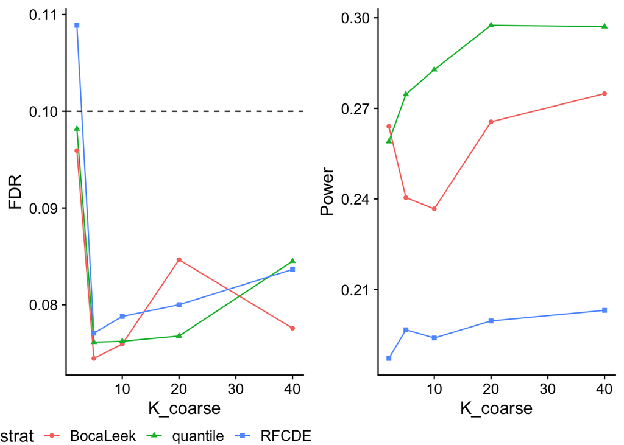

```r
eval_group_sim <- rbind(
  eval_ihw_grouped_sim_quantile,
  eval_ihw_grouped_sim_RFCDE,
  eval_ihw_grouped_sim_bocaleek
)

plot1(eval_group_sim, "K_coarse")
```

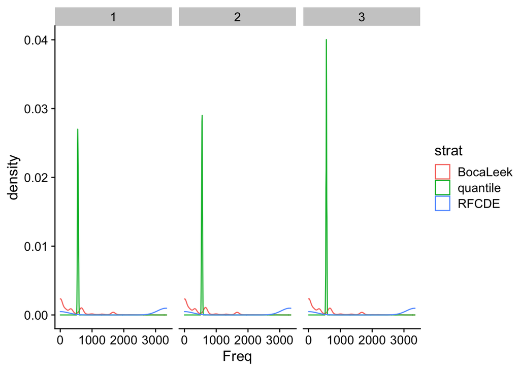

```r
freq_grouped_sim <- rbind(
  get_freq(ihw_grouped_sim_bocaleek, strat = "BocaLeek"),
  get_freq(ihw_grouped_sim_RFCDE, strat = "RFCDE"),
  get_freq(ihw_grouped_sim_quantile, strat = "quantile")
)

plot_freq_grouped_sim <- ggplot(freq_grouped_sim, aes(x = Freq, color = strat)) +
  geom_density() +
  facet_wrap(~fold)
plot_freq_grouped_sim
```

## 2. BetaMix Example

Now we create the betamix sample data according to Section 5.2 in https://doi.org/10.1111/rssb.12411 with two-dimensional covariates

```r
betamix_sim_combs <- expand.grid(
  mu_slope = seq(1, 3, length = 7),
  seed = seq_len(r)
)

betamix_sim <- foreach(i = 1:nrow(betamix_sim_combs)) %dorng% {
  betamix_sim_i <- IHWStatsPaper::beta_unif_sim(m = m, mus_slope = betamix_sim_combs$mu_slope[i], one_sided_tests = FALSE, prob_one_sided = 0.25)
  betamix_sim_i$Xs <- as.matrix(betamix_sim_i$Xs)
  colnames(betamix_sim_i$Xs) <- c("X1", "X2")
  betamix_sim_i
}
```

```r
ihw_betamix_bocaleek <- foreach(betamix_sim_i = betamix_sim) %dopar% {
  Xs_i = betamix_sim_i$Xs
  Ps_i = betamix_sim_i$Ps
  ihw_forest_bocaleek_i <- ihw(Ps_i, Xs_i, alpha = alpha, folds = folds, strat = "BocaLeek", ntrees = ntrees, tau = tau, lambda = lambda)
}
eval_ihw_betamix_bocaleek <- fdp_eval_ihw(strat = "BocaLeek", ihw_res = ihw_betamix_bocaleek, sim_par = betamix_sim_combs, sim = betamix_sim)
```

```r
ihw_betamix_RFCDE <- calc_ihw(strat = "RFCDE", sim = betamix_sim, alpha = alpha, folds = folds, ntrees = ntrees, tau = tau, lambda = lambda)
eval_ihw_betamix_RFCDE <- fdp_eval_ihw(strat = "RFCDE", ihw_res = ihw_betamix_RFCDE, sim_par = betamix_sim_combs, sim = betamix_sim)
```

To run the original IHW (quantile slicing) on two-dimensional covariates, we need to manually bin the covariates in 2d squares

```r
bins1d <- seq(from = 0, to = 1, length.out = 6)
Xs_binned <- foreach(betamix_sim_i = betamix_sim) %dopar% {
  Xs_i = betamix_sim_i$Xs
  Xs_binned_i <- data.frame(
    X1 = cut(Xs_i[, 1], bins1d),
    X2 = cut(Xs_i[, 2], bins1d)
  )
  Xs_binned_i <- apply(Xs_binned_i, 1, function(row) {
    factor(paste(row[[1]], row[[2]], sep = "*"))
  })
  Xs_binned_i
}
```

We run the normal IHW with the binned covariates. The option `strat = "quantile"` makes it equivalent to the original IHW. #TODO this is nominal

```r
Ps <- lapply(betamix_sim, function (betamix_sim_i) betamix_sim_i$Ps)
ihw_betamix_quantile <- calc_ihw(strat = "quantile", Ps = Ps, Xs = Xs_binned, alpha = alpha, folds = folds, ntrees = ntrees, tau = tau, lambda = lambda)
eval_ihw_betamix_quantile <- fdp_eval_ihw(strat = "quantile", ihw_res = ihw_betamix_quantile, sim_par = betamix_sim_combs, sim = betamix_sim)
```

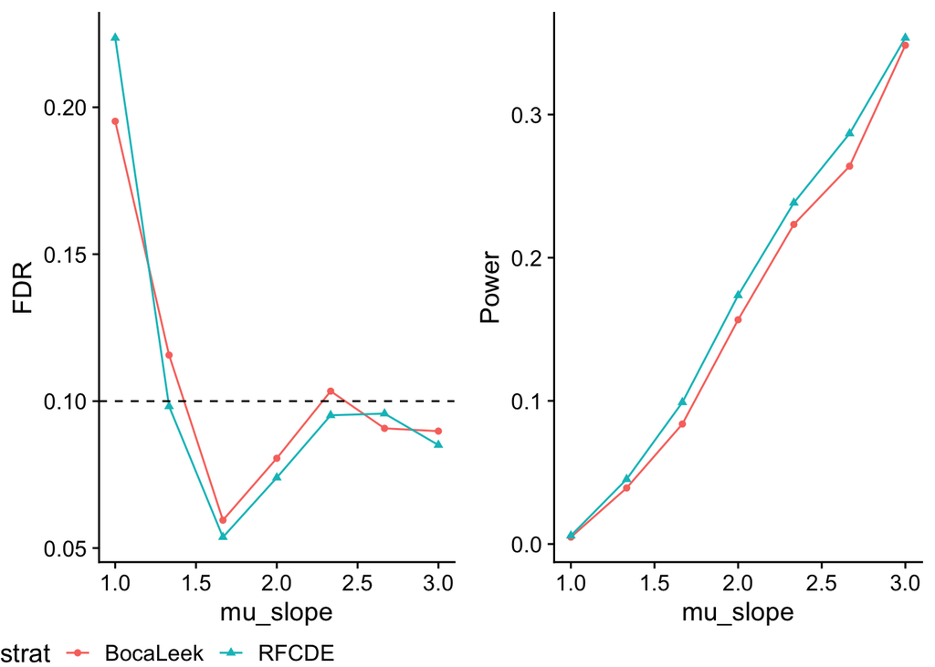

```r
eval_betamix_sim <- rbind(
  eval_ihw_betamix_bocaleek,
  eval_ihw_betamix_RFCDE#,
  #eval_ihw_betamix_quantile
)

plot1(eval_betamix_sim, "mu_slope")
```

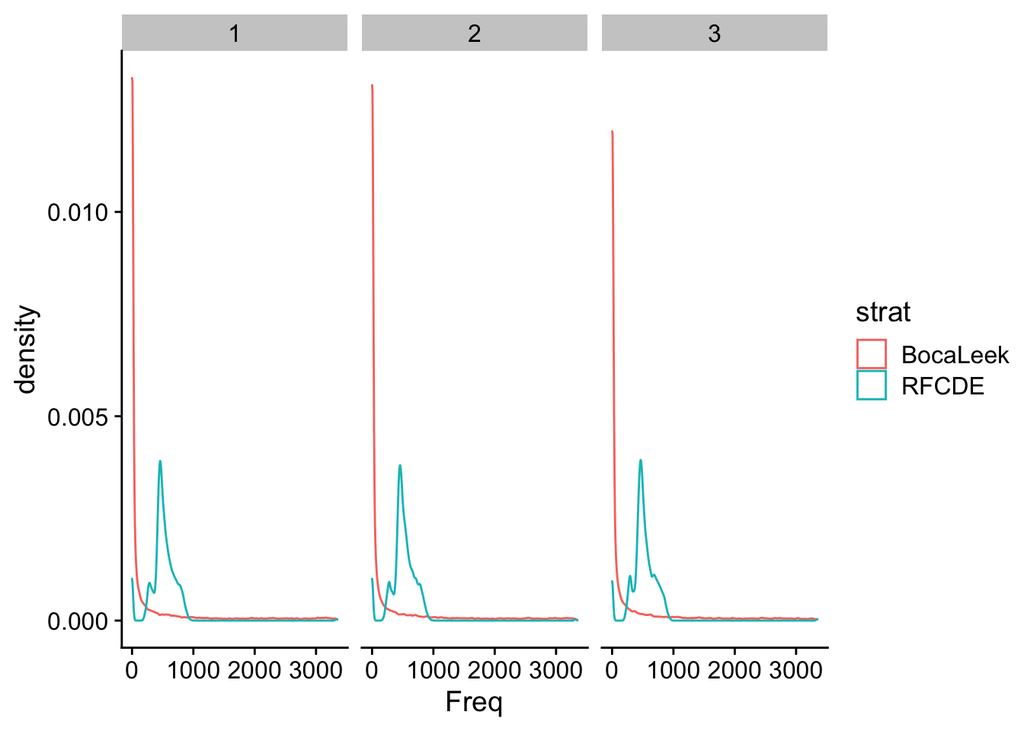

```r
freq_betamix <- rbind(
  get_freq(ihw_betamix_bocaleek, strat = "BocaLeek"),
  get_freq(ihw_betamix_RFCDE, strat = "RFCDE")#,
  #get_freq(ihw_betamix_quantile, strat = "quantile")
)

plot_freq_betamix <- ggplot(freq_betamix, aes(x = Freq, color = strat)) +
  geom_density() +
  facet_wrap(~fold)
plot_freq_betamix
```

## 3. BetaMix with noise

Lets add some uninformative noise. If this still works, this would be extremely convenient for the end user. Furthermore, so many dimensions definitely necessitates the use of regression trees. Due to the exponential increase of the number of bins with the dimension, quantile slicing would be computationally infeasible. The ability to incorporate high-dimensional covariates is the most convincing advantage of the random forest approach.

```r
Xs_noise <- foreach(betamix_sim_i = betamix_sim) %dopar% {
  Xs_i = betamix_sim_i$Xs
  noise <- matrix(runif(m * 5), nrow = m)
  Xs_noise_i <- cbind(Xs_i, noise)
  colnames(Xs_noise_i) <- paste0("X",1:7)
  Xs_noise_i <- as.matrix(Xs_noise_i)
  Xs_noise_i
}
```

```r
ihw_betamix_noise_bocaleek <- foreach(Xs_noise_i = Xs_noise, betamix_sim_i = betamix_sim) %dopar% {
  Ps_i <- betamix_sim_i$Ps
  ihw(Ps_i, Xs_noise_i, alpha = alpha, folds = folds, strat = "BocaLeek", ntrees = ntrees, tau = tau, lambda = lambda)
}
eval_ihw_betamix_noise_bocaleek <- fdp_eval_ihw(strat = "BocaLeek", ihw_res = ihw_betamix_noise_bocaleek, sim = betamix_sim, sim_par = betamix_sim_combs)
```

TODO

```r
ihw_betamix_noise_RFCDE <- foreach(Xs_noise_i = Xs_noise, betamix_sim_i = betamix_sim) %dopar% {
  Ps_i <- betamix_sim_i$Ps
  ihw(Ps_i, Xs_noise_i, alpha = alpha, folds = folds, strat = "RFCDE", ntrees = ntrees, tau = tau, lambda = lambda)
}
#eval_ihw_betamix_noise_RFCDE <- fdp_eval_ihw(strat = "RFCDE", ihw_res = ihw_betamix_noise_RFCDE, sim = betamix_sim, sim_par = betamix_sim_combs)
```

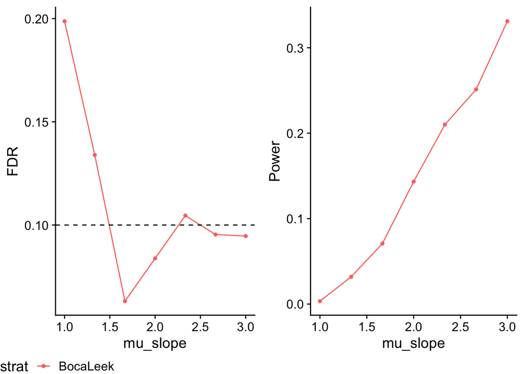

```r
eval_betamix_noise_sim <- rbind(
  eval_ihw_betamix_noise_bocaleek#,
  #eval_ihw_betamix_noise_RFCDE #TODO
)

plot1(eval_betamix_noise_sim, "mu_slope") #TODO too many rows, bug
```

## 4. But does it work better in univariate case?

Lets return to a simple, univariate example. The official referencemanual (http://bioconductor.org/packages/release/bioc/manuals/IHW/man/IHW.pdf) works with following data.

```r
Xs <- lapply(1:r, function(i) {
  runif(m, min = 0, max = 2.5) # covariate
})
Hs <- lapply(1:r, function(i) {
  rbinom(m, 1, 0.1) # hypothesis true or false
})
Ps <- lapply(1:r, function(i) {
  Xs_i <- Xs[[i]]
  Hs_i <- Hs[[i]]
  Z_i <- rnorm(m, Hs_i * Xs_i) # Z-score
  Ps_i <- 1 - pnorm(Z_i) # pvalue
})
```

Lets run IHW forest and the quantile slicing on this:

```r
ihw_univ_quantile <- foreach(Xs_i = Xs, Ps_i = Ps) %dopar% {
  ihw(Ps_i, Xs_i, alpha = alpha, folds = folds, strat = "quantile", lambda = lambda)
}
eval_ihw_univ_quantile <- fdp_eval_ihw(strat = "quantile", ihw_res = ihw_univ_quantile, Hs = Hs)
```

And now we run IHW forest.

```r
ihw_univ_bocaleek <- foreach(Xs_i = Xs, Ps_i = Ps) %dopar% {
  ihw(Ps_i, Xs_i, alpha = alpha, folds = folds, strat = "BocaLeek", ntrees = ntrees, tau = tau, lambda = lambda)
}
eval_ihw_univ_bocaleek <- fdp_eval_ihw(strat = "BocaLeek", ihw_res = ihw_univ_bocaleek, Hs = Hs)
```

So it turns out, that using the Boca Leek Tree actually did harm in this case.

```r
ihw_univ_RFCDE <- foreach(Xs_i = Xs, Ps_i = Ps) %dopar% {
  ihw(Ps_i, Xs_i, alpha = alpha, folds = folds, strat = "RFCDE", ntrees = ntrees, tau = tau, lambda = lambda)
}
eval_ihw_univ_RFCDE <- fdp_eval_ihw(strat = "RFCDE", ihw_res = ihw_univ_RFCDE, Hs = Hs)
```

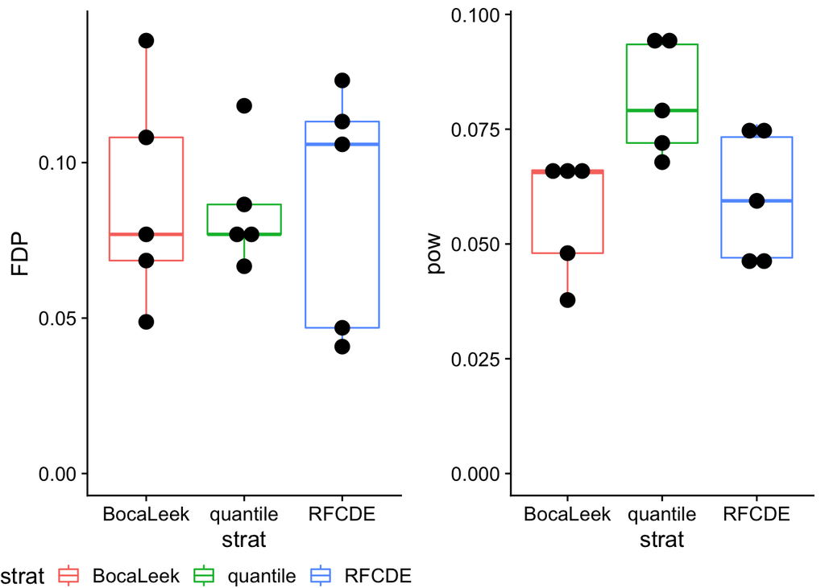

```r
eval_ihw_univ <- rbind(eval_ihw_univ_quantile, eval_ihw_univ_bocaleek, eval_ihw_univ_RFCDE)

eval_ihw_univ_FDR <- ggplot(eval_ihw_univ, aes(x=strat, y=FDP)) +
    geom_boxplot(aes(color=strat)) +
   geom_dotplot(binaxis='y', stackdir='center', dotsize=1)+
  ylim(0,NA)

eval_ihw_univ_power <- ggplot(eval_ihw_univ, aes(x=strat, y=pow)) +
    geom_boxplot(aes(color=strat)) +
   geom_dotplot(binaxis='y', stackdir='center', dotsize=1) +
  ylim(0,NA)

ggarrange(eval_ihw_univ_FDR, eval_ihw_univ_power, nrow = 1, widths = c(1, 1), common.legend = TRUE, legend = "bottom")
```

## 5. Airway data seit

Let’s try some real biological data instead of simulation. We are not able check the FDR, but we are confident it is controlled. We benchmark on the airway data set, also used in the official vigniette (http://bioconductor.org/packages/release/bioc/vignettes/IHW/inst/doc/introduction_to_ihw.html). You can download the necessary packages `BiocManager::install("airway")` and `BiocManager::install("DESeq2")`.

```r
library("DESeq2")
data("airway", package = "airway")
dds <- DESeq2::DESeqDataSet(se = airway, design = ~ cell + dex) %>% DESeq()
deRes <- as.data.frame(results(dds))
```

setting some parameters

```r
m <- nrow(deRes)
folds <- sample(1:nfolds, m, replace = TRUE)
```

We first run the original IHW.

```r
ihw_airway_quantile <- ihw(pvalue ~ baseMean, data = deRes, alpha = alpha, folds = folds, lambda = lambda, strat = "quantile")
```

[output not shown]

[output cut: 122 more lines]

[output not shown]

```
## We recommend that you supply (many) more than 1000 p-values for meaningful data-driven hypothesis weighting results.
```

[output not shown]

[output cut: 25 more lines]

[output not shown]

And then IHW forest.

```r
ihw_airway_forest <- ihw(pvalue ~ baseMean, data = deRes, alpha = alpha, folds = folds, strat = "BocaLeek", ntrees = ntrees, tau = tau, lambda = lambda)
```

[output not shown]

[output cut: 215 more lines]

[output not shown]

```r
ihw_airway_RFCDE <- ihw(pvalue ~ baseMean, data = deRes, alpha = alpha, folds = folds, strat = "RFCDE", ntrees = ntrees, tau = tau, lambda = lambda)
```

[output not shown]

[output cut: 219 more lines]

[output not shown]

Again, the we are actually worse off with the new method…

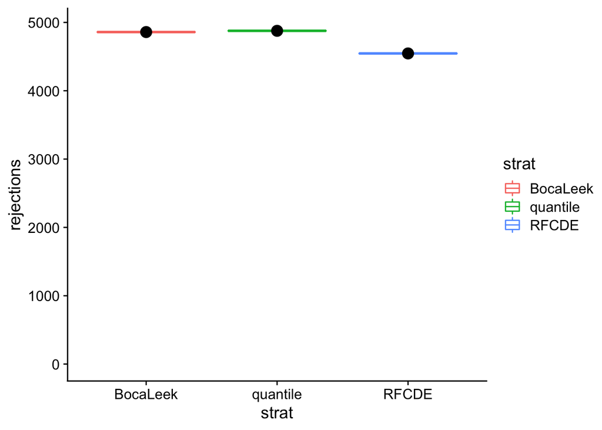

```r
eval_ihw_airway <- data.frame(all_rjs = c(rejections(ihw_airway_quantile) ,
                       rejections(ihw_airway_forest) ,
                       rejections(ihw_airway_RFCDE)
                       ),
           strat = c("quantile", "BocaLeek", "RFCDE"))

eval_ihw_univ_FDR <- ggplot(eval_ihw_airway, aes(x=strat, y=all_rjs)) +
    geom_boxplot(aes(color=strat)) +
   geom_dotplot(binaxis='y', stackdir='center', dotsize=1)+
  ylim(0,NA) +
  ylab("rejections")
eval_ihw_univ_FDR
```

## Conclusion/Outlook

Further outlook: I want to restore the auto setting functionality of lambda and fold. Unfortunately, this is tricky, because major changes to the original code/order functions are executed are required. This is not a good problem for a code review session. Furthermore, the code in https://raw.github.com/FridljDa/IHW/main/bioconductor/R/ihw_convex_20211214.R is currently pretty hacky and not good enough for BioConductor.